# Machine Learning for Natural Language Processing

Dr Saliha Minhas

**Audience:** Diverse Background

**Time:** (2 hours)

**Pre-Requisites:** : Completion of an introductory course in Python

**Brief Description:** This 2 hour workshop will illustrate how text can be processed for predictive modelling using a machine learning based classification algorithm in key problem domains.

**Aims, Objectives and Intended Learning Outcomes:** All participants through completion of this workshop should have an understanding of the pipeline used to clean and preprocess natural language and steps involved in preparing the data for a classification task using machine learning algorithms.

**Dataset:** `BBC News headline Dataset`, `Airline tweets sentiments Dataset`, `IATI (descriptions on aid activity) dataset`

**Libraries:** Before attending the course please make sure that you read course instructions received

**Acknowledgements:** Many thanks to the Science and Engineering team at GIC for proposing and hosting this workshop.

## Chapter 1: Classification

- Describe suoervised machine learning
- Describe what is classification with reference to use cases
- Outline the tasks undertaken to perform task classification
- Describe how an imbalanced dataset can affect performance metrics of a classifer
- Perform commonly applied exploratory analysis on dataset
- Outline the tasks undertaken to perform task classification
- List the ways in which text can be transfornmed to numerical values
- Use Python’s scilearn library to transform text to tf-idf scores
- Undertake steps outlined to clean text
- Split data into train and test using scilearn
- Set hyerparameters to the SVM model
- Run the test set through model
- Interpret performance metrics

### 3.1 What is Machine Learning?

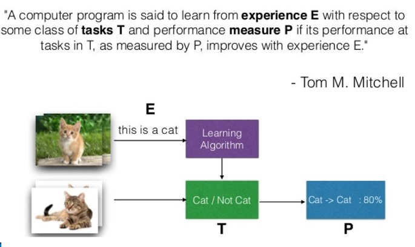

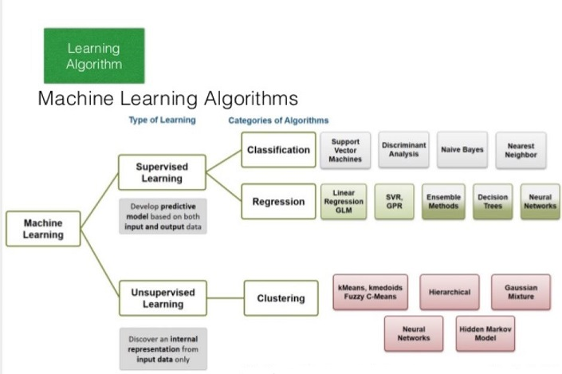

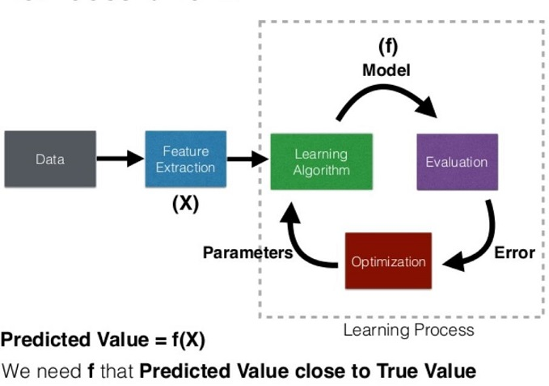

Machine Learning algorithms enable a machine to learn from examples. Only **supervised** machine learning will be investigated here. Using the examples - known as a trainng set, our chosen algorithm establishes a function for example as below:-

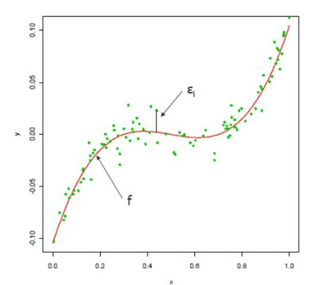

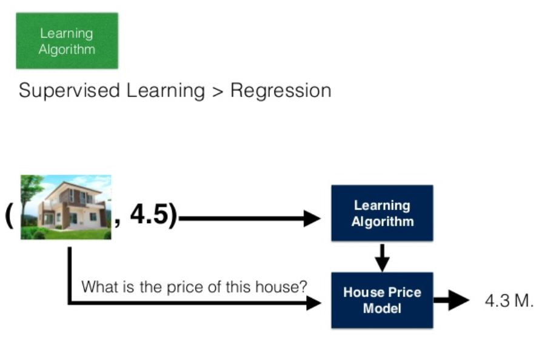

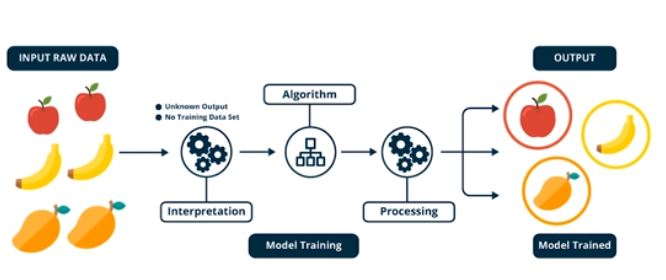

### 3.2 What is Text Classification?

Text classification is a typical task in **supervised** machine learning (ML). Assigning categories to documents, which can be a web page, library book, media articles, gallery etc. has many applications like e.g. spam filtering, email routing, sentiment analysis etc.

An algorithm specifies which of *k* categories some input belongs to. To solve this task, the learning algorithm is usually asked to produce a function f(Real number) → {1, . . . , k}. When y=f(x), the model assigns an input described by vector x to a category identiﬁed by numeric code y.

The machine must predict the most probable category, class, or label for new examples.

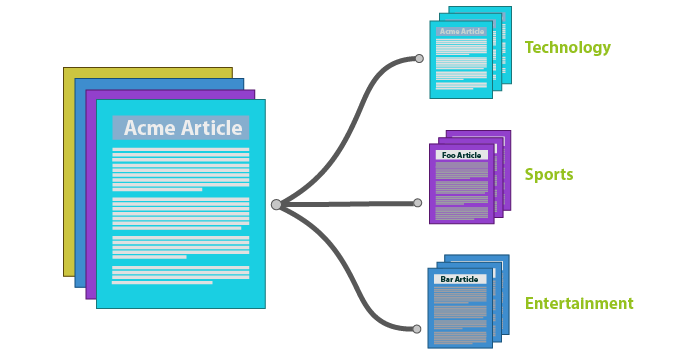

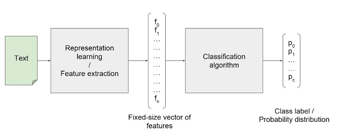

**Why do we need to classify text?**

- As an independent task

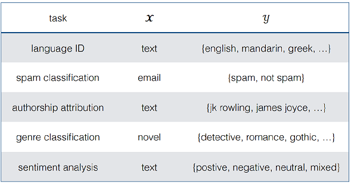

- As part of more complicated NLP tasks
  - Data filtering
  - Intent classification in dialog systems
  - Hybrid machine translation systems

**High-level workflow of a text classification project**

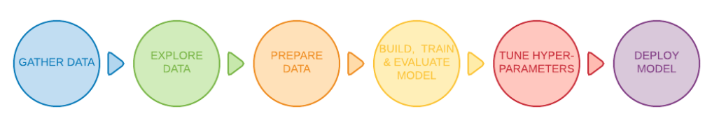

The dataset used in this project is the BBC News Raw Dataset. It can be downloaded from [here](http://mlg.ucd.ie/datasets/bbc.html) It consists of 2,225 documents from the BBC news website corresponding to stories in five topical areas from 2004 to 2005. These areas are:

- Business
- Entertainment
- Politics
- Sport
- Tech

One of our main concerns when developing a classification model is whether the different classes are balanced . This means that the dataset contains an approximately equal portion of each class. For example, if we had two classes and a 95% of observations belonging to one of them, a dumb classifier which always output the majority class would have 95% accuracy, although it would fail all the predictions of the minority class. There are several ways of dealing with imbalanced datasets . One first approach is to undersample the majority class and oversample the minority one, so as to obtain a more balanced dataset. Other approach can be using other error metrics beyond accuracy such as the precision , the recall or the F1-score . These metrics are examined later. Looking at BBC News data, the % of observations belonging to each class can be obtained.

### 3.3 Exploratory Data Analysis

It is a common practice to carry out an exploratory data analysis in order to gain some insights from the data.

```python
import pandas as pd
import matplotlib.pyplot as plt
import pickle
import seaborn as sns
sns.set_style("whitegrid")
import altair as alt



##read in data
df = pd.read_csv("C:/data/BBC/News_dataset.csv", sep=';')


#look at dimensions

df.shape


##look at top 6
```

```
## (2225, 4)
```

```python
df.head()


##look at data in content column
```

```
##   File_Name                                            Content  Category  \
## 0   001.txt  Ad sales boost Time Warner profit\r\n\r\nQuart...  business
## 1   002.txt  Dollar gains on Greenspan speech\r\n\r\nThe do...  business
## 2   003.txt  Yukos unit buyer faces loan claim\r\n\r\nThe o...  business
## 3   004.txt  High fuel prices hit BA's profits\r\n\r\nBriti...  business
## 4   005.txt  Pernod takeover talk lifts Domecq\r\n\r\nShare...  business
##
##   Complete_Filename
## 0  001.txt-business
## 1  002.txt-business
## 2  003.txt-business
## 3  004.txt-business
## 4  005.txt-business
```

```python
df['Content'].head()


#look at the content in the first row
```

```
## 0    Ad sales boost Time Warner profit\r\n\r\nQuart...
## 1    Dollar gains on Greenspan speech\r\n\r\nThe do...
## 2    Yukos unit buyer faces loan claim\r\n\r\nThe o...
## 3    High fuel prices hit BA's profits\r\n\r\nBriti...
## 4    Pernod takeover talk lifts Domecq\r\n\r\nShare...
## Name: Content, dtype: object
```

```python
df.loc[1, 'Content']
```

```
## 'Dollar gains on Greenspan speech\r\n\r\nThe dollar has hit its highest level against the euro in almost three months after the Federal Reserve head said the US trade deficit is set to stabilise.\r\n\r\nAnd Alan Greenspan highlighted the US government\'s willingness to curb spending and rising ho…
```

```python
#get all data from category and ut in list
cat = list(df['Category'])

#get all  unique values
cat2 = set(cat)

#add counts to dictionary
dict1 = {}
for value in cat2:
    dict1[value] = cat.count(value)

print (dict1)
```

```
## {'business': 510, 'tech': 401, 'entertainment': 386, 'sport': 511, 'politics': 417}
```

[figure not shown]

```python
plot contents of dictionary
plt.bar(range(len(dict1)), dict1.values(), align='center')
plt.xticks(range(len(dict1)), list(dict1.keys()))

plt.show()
```

```python
#length of each news article
df['News_length'] = df['Content'].str.len()

# have a look at top 6
df['News_length'].head()


#get basic stats on column
```

```
## 0    2569
## 1    2257
## 2    1557
## 3    2421
## 4    1575
## Name: News_length, dtype: int64
```

```python
df['News_length'].describe()

#how many articles with more than 10k words
```

```
## count     2225.000000
## mean      2274.363596
## std       1370.782663
## min        506.000000
## 25%       1454.000000
## 50%       1978.000000
## 75%       2814.000000
## max      25596.000000
## Name: News_length, dtype: float64
```

```python
df_more10k = df[df['News_length'] > 10000]
len(df_more10k)


#95 percent of values have a news length  of value given by quantile
```

```
## 7
```

```python
quantile_95 = df['News_length'].quantile(0.95)
print (quantile_95)
```

```
## 4304.0
```

```python
df_95 = df[df['News_length'] < quantile_95]

#get only category and newslength
df_95_2 = df_95[['Category', 'News_length']]

#have a look at it
df_95_2.head()

# all categories
```

```
##    Category  News_length
## 0  business         2569
## 1  business         2257
## 2  business         1557
## 3  business         2421
## 4  business         1575
```

```python
print (cat2)
```

```
## {'business', 'tech', 'entertainment', 'sport', 'politics'}
```

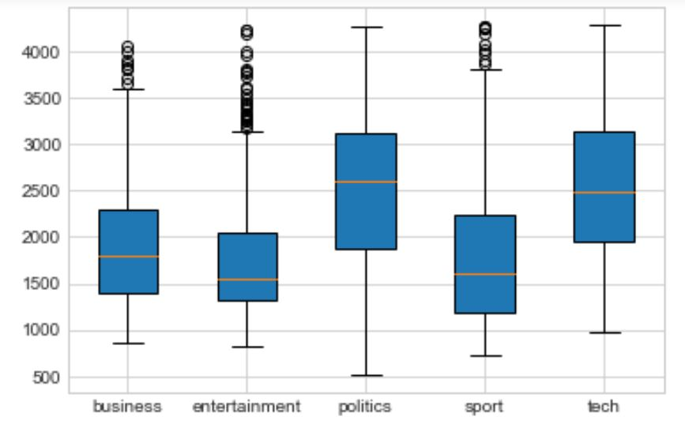

```python
#make box plot
dictc = {}

for value in cat2:

     news_len = df_95_2[df_95_2['Category'] == value]
     news_len = list (news_len['News_length'])
     dictc[value]= news_len


dictc['business'][0:6]


box_plot_data=[dictc['business'],dictc['entertainment'],dictc['politics'],dictc['sport'], dictc['tech']]
plt.boxplot(box_plot_data,patch_artist=True,labels=['business', 'entertainment','politics','sport','tech'])
plt.show()
```

Nice explanation on box plots here:https://towardsdatascience.com/understanding-boxplots-5e2df7bcbd51

### 3.4 Text Cleaning

Before creating any feature from the raw text, we must perform a cleaning process to ensure no distortions are introduced to the model to be used.

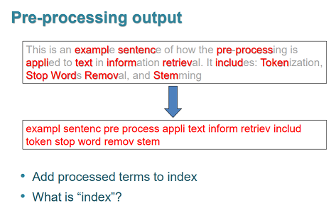

**See NLP Intro course for further explanation** https://github.com/salihadfid1/NLPINTROLIVE/blob/master/Intro-to-NLP-v4.html

### 3.5 Feature Engineering

With ML tasks, it is possible to generate useful feature in a variety of ways. For example:

- General statistics: text length, text length variance
- Scores from tagged lists
- Sentiment dictionaries: SentiWordNet, SentiWords
- Subjectivity/Objectivity dictionaries: MPQA
- Syntactic features
- POS tags
- Ad-hoc features: eg number of emojis

Feature engineering is an essential part of building any intelligent system. As Andrew Ng says:  
*“Coming up with features is difficult, time-consuming, requires expert knowledge. ‘Applied machine learning’ is basically feature engineering.”*  
Feature engineering is the process of * transforming data into features to act as inputs for machine learning models such that good quality features help in improving the model performance.  
When dealing with text data, there are several ways of obtaining features that represent the data. A few common methods are delineated below.

#### 3.5.1 Text Representation

In order to represent our text, every row of the dataset will be a single document of the corpus. The columns (features) will be different depending of which feature creation method we choose:  
**Word Count Vectors**  
With this method, every column is a term from the corpus, and every cell represents the frequency count of each term in each document.  
**TF–IDF Vectors**  
TF-IDF is a score that represents the relative importance of a term in the document and the entire corpus.  
**See NLP Intro course for further explanation**  
https://github.com/salihadfid1/NLPINTROLIVE/blob/master/Intro-to-NLP-v4.html

These two methods (Word Count Vectors and TF-IDF Vectors) are often named Bag of Words method, since the order of the words in a sentence is ignored. The following methods are more advanced as they somehow preserve the order of the words and their lexical considerations.  
**Word Embeddings**  
The position of a word within the vector space is learned from text and is based on the words that surround the word when it is used.  
**See NLP Intro course for further explanation**  
**Text based or NLP based featuress**  
We can manually create any feature that we think may be of importance when discerning between categories (i.e. word density, number of characters or words, etc…). We can also use NLP based features using Part of Speech models, which can tell us, for example, if a word is a noun or a verb, and then use the frequency distribution of the PoS tags.  
**Topic Models**  
Methods such as **Latent Dirichlet Allocation** attempts to represent every topic by a probabilistic distribution over words, in what is known as **topic modeling**

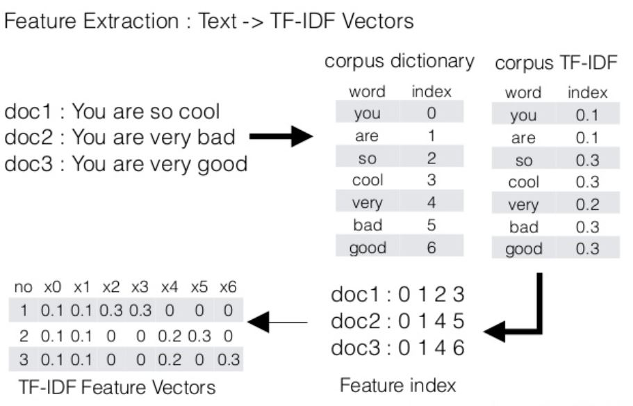

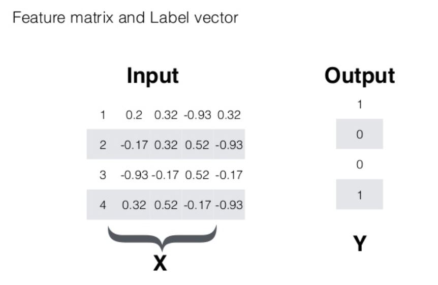

TF-IDF vectors have been chosen to represent the documents in this BBC dataset corpus due to its simplicity and speed in the creation of vectors.

When creating the features with this method, some parameters have to be chosen:  
N-gram range: unigrams, bigrams, trigrams ?  
Maximum/Minimum Document Frequency: when building the vocabulary, ignore terms that have a document frequency strictly higher/lower than the given threshold.  
Maximum features: Choose the top N features ordered by term frequency across the corpus.  
The following parameters have been chosen:

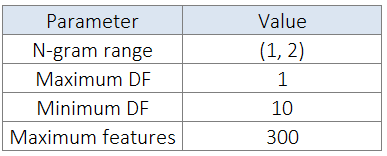

### 3.6 Label Coding

Machine learning models require numeric features and labels to provide a prediction. A dictionary to map each label to a numerical ID has been created. This mapping scheme is as below:

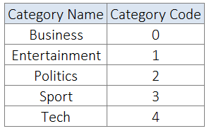

### 3.7 Train — Test split

A test set needs to be set up in order to prove the quality of the models when predicting on unseen data.  
A random split with 85% of the observations composing the training test and 15% of the observations composing the test set will be established. The following steps are then undertaken:

- Hyperparameter tuning
- Establish the final model
- Evaluate it with the test set
- Assess performance metrics

```python
import pandas as pd
import matplotlib.pyplot as plt
import numpy as np
from collections import Counter
import random
import nltk
from nltk.stem import WordNetLemmatizer
import re
from nltk.corpus import wordnet
from nltk.corpus import stopwords
from sklearn.feature_extraction.text import TfidfVectorizer
from sklearn.model_selection import train_test_split
from sklearn.feature_selection import chi2
import os
os.chdir("C:/IR Course/Adv -IR/")
import pickle
from sklearn.ensemble import RandomForestClassifier
from sklearn import svm
from pprint import pprint
from sklearn.model_selection import RandomizedSearchCV
from sklearn.model_selection import GridSearchCV
from sklearn.metrics import classification_report, confusion_matrix, accuracy_score
from sklearn.model_selection import ShuffleSplit
plt.style.use('ggplot')


def set_tokens_to_lowercase(data):
    for index, entry in enumerate(data):
        data[index] = entry.lower()
    return data


def remove_punctuation(data):
    symbols = ",.!"
    for index, entry in enumerate(symbols):
        for index2, entry2 in enumerate (data):
            data[index2] = re.sub(r'[^\w]', ' ', entry2)
    return data

def remove_stopwords_from_tokens(data):
       stop_words = set(stopwords.words("english"))
       new_list = []
       for index, entry in enumerate(data):
           no_stopwords = ""
           entry = entry.split()
           for word in entry:
               if word not in stop_words:
                    no_stopwords = no_stopwords + " " + word
           new_list.append(no_stopwords)
       return new_list

def lemmatiser (pdf, pcol):
    wordnet_lemmatizer = WordNetLemmatizer()
    lemmatized_text_list = []



    for row in range(len(pdf)):


        # Create an empty list containing lemmatized words
        lemmatized_list = []

        # Save the text and its words into an object
        text = pdf.loc[row, pcol]
        #print(text)

        text_words = text.split(" ")

        # Iterate through every word to lemmatize
        for word in text_words:
            lemmatized_list.append(wordnet_lemmatizer.lemmatize(word, pos="v"))

        # Join the list
        lemmatized_text = " ".join(lemmatized_list)

        # Append to the list containing the texts
        lemmatized_text_list.append(lemmatized_text)
    return lemmatized_text_list
```

```python
# remove  \r and \n
df['Content_Parsed_1'] = df['Content'].str.replace("\r", " ")
df['Content_Parsed_1'] = df['Content_Parsed_1'].str.replace("\n", " ")
# Lowercasing the text
df['Content_Parsed_2'] = df['Content_Parsed_1'].str.lower()
# remove punctuation
df['Content_Parsed_3'] = pd.Series(remove_punctuation (list(df['Content_Parsed_2'])))
#remove possessive
df['Content_Parsed_4'] = df['Content_Parsed_3'].str.replace("'s", "")
df.head()
```

```
##   File_Name                                            Content  Category  \
## 0   001.txt  Ad sales boost Time Warner profit\r\n\r\nQuart...  business
## 1   002.txt  Dollar gains on Greenspan speech\r\n\r\nThe do...  business
## 2   003.txt  Yukos unit buyer faces loan claim\r\n\r\nThe o...  business
## 3   004.txt  High fuel prices hit BA's profits\r\n\r\nBriti...  business
## 4   005.txt  Pernod takeover talk lifts Domecq\r\n\r\nShare...  business
##
##   Complete_Filename  News_length  \
## 0  001.txt-business         2569
## 1  002.txt-business         2257
## 2  003.txt-business         1557
## 3  004.txt-business         2421
## 4  005.txt-business         1575
##
##                                     Content_Parsed_1  \
```

[output cut: 26 more lines]

```python
#lemmatise
df['Content_Parsed_5'] = lemmatiser (df, 'Content_Parsed_4')

df['Content_Parsed_6'] = df['Content_Parsed_5']

#remove stopwords
df['Content_Parsed_6'] = pd.Series(remove_stopwords_from_tokens(list(df['Content_Parsed_6'])))

list_columns = ["File_Name", "Category", "Complete_Filename", "Content", "Content_Parsed_6"]
df = df[list_columns]

df = df.rename(columns={'Content_Parsed_6': 'Content_Parsed'})

print(df.loc[3,'Content_Parsed'])
```

```
##  high fuel price hit ba profit british airways blame high fuel price 40 drop profit report result three months 31 december 2004 airline make pre tax profit â 75m 141m compare â 125m year earlier rod eddington ba chief executive say result respectable third quarter fuel cost rise â 106m 47 3 ba pr…
```

```python
df.head()
```

```
##   File_Name  Category Complete_Filename  \
## 0   001.txt  business  001.txt-business
## 1   002.txt  business  002.txt-business
## 2   003.txt  business  003.txt-business
## 3   004.txt  business  004.txt-business
## 4   005.txt  business  005.txt-business
##
##                                              Content  \
## 0  Ad sales boost Time Warner profit\r\n\r\nQuart...
## 1  Dollar gains on Greenspan speech\r\n\r\nThe do...
## 2  Yukos unit buyer faces loan claim\r\n\r\nThe o...
## 3  High fuel prices hit BA's profits\r\n\r\nBriti...
## 4  Pernod takeover talk lifts Domecq\r\n\r\nShare...
##
##                                       Content_Parsed
## 0   ad sales boost time warner profit quarterly p...
## 1   dollar gain greenspan speech dollar hit highe...
## 2   yukos unit buyer face loan claim owners embat...
## 3   high fuel price hit ba profit british airways...
## 4   pernod takeover talk lift domecq share uk dri...
```

**ADD LABELS**

```python
category_codes = {
    'business': 0,
    'entertainment': 1,
    'politics': 2,
    'sport': 3,
    'tech': 4
}

# Category mapping
df['Category_Code'] = df['Category']
df = df.replace({'Category_Code':category_codes})


## ensure no other category in dataframe

for index, row in df.iterrows():
    if row['Category_Code'] not in [0,1,2,3,4]:
         df = df.drop (index)

df.tail()
```

```
##      File_Name Category Complete_Filename  \
## 2220   397.txt     tech      397.txt-tech
## 2221   398.txt     tech      398.txt-tech
## 2222   399.txt     tech      399.txt-tech
## 2223   400.txt     tech      400.txt-tech
## 2224   401.txt     tech      401.txt-tech
##
##                                                 Content  \
## 2220  BT program to beat dialler scams\r\n\r\nBT is ...
## 2221  Spam e-mails tempt net shoppers\r\n\r\nCompute...
## 2222  Be careful how you code\r\n\r\nA new European ...
## 2223  US cyber security chief resigns\r\n\r\nThe man...
## 2224  Losing yourself in online gaming\r\n\r\nOnline...
##
##                                          Content_Parsed  Category_Code
## 2220   bt program beat dialler scam bt introduce two...              4
## 2221   spam e mail tempt net shoppers computer users...              4
## 2222   careful code new european directive could put...              4
## 2223   us cyber security chief resign man make sure ...              4
## 2224   lose online game online role play game time c...              4
```

**TRAIN - TEST SPLIT**

To prove the quality of the model a subset of the data is set apart for testing. The training data is used to tune hyperparameters and then test performance on the unseen data of the test set.

Test set size of 15% of the full dataset is used.

```python
X_train, X_test, y_train, y_test = train_test_split(df['Content_Parsed'],
                                                    df['Category_Code'],
                                                    test_size=0.15,
                                                    random_state=8)
```

**PARAMETERS FOR tfidfvectorizer in SCILEARN**

```python
# Parameter election
ngram_range = (1,2)
min_df = 10
max_df = 1.
max_features = 300
```

```python
tfidf = TfidfVectorizer(encoding='utf-8',
                        ngram_range=ngram_range,
                        stop_words=None,
                        lowercase=False,
                        max_df=max_df,
                        min_df=min_df,
                        max_features=max_features,
                        norm='l2',
                        sublinear_tf=True)



features_train = tfidf.fit_transform(X_train).toarray()
labels_train = y_train
labels_train = np.array(labels_train, dtype=np.int)

#training data
print(features_train.shape)
```

```
## (1891, 300)
```

```python
features_test = tfidf.transform(X_test).toarray()
labels_test = y_test
labels_test = np.array(labels_test, dtype=np.int)


#test data
print(features_test.shape)
```

```
## (334, 300)
```

```python
for Product, category_id in sorted(category_codes.items()):
    features_chi2 = chi2(features_train, labels_train == category_id)
    indices = np.argsort(features_chi2[0])
    feature_names = np.array(tfidf.get_feature_names())[indices]
    unigrams = [v for v in feature_names if len(v.split(' ')) == 1]
    bigrams = [v for v in feature_names if len(v.split(' ')) == 2]
    print("# '{}' category:".format(Product))
    print("  . Most correlated unigrams:\n. {}".format('\n. '.join(unigrams[-5:])))
    print("  . Most correlated bigrams:\n. {}".format('\n. '.join(bigrams[-2:])))
    print("")
```

```
## # 'business' category:
##   . Most correlated unigrams:
## . firm
## . market
## . economy
## . growth
## . bank
##   . Most correlated bigrams:
## . last year
## . year old
##
## # 'entertainment' category:
##   . Most correlated unigrams:
## . tv
## . music
## . star
## . award
## . film
##   . Most correlated bigrams:
## . mr blair
## . prime minister
##
## # 'politics' category:
##   . Most correlated unigrams:
## . minister
## . blair
## . election
## . party
## . labour
##   . Most correlated bigrams:
## . prime minister
## . mr blair
##
## # 'sport' category:
##   . Most correlated unigrams:
## . win
## . side
## . game
## . team
## . match
##   . Most correlated bigrams:
## . say mr
## . year old
##
## # 'tech' category:
##   . Most correlated unigrams:
## . digital
## . technology
## . computer
## . software
## . users
##   . Most correlated bigrams:
## . year old
## . say mr
```

### 3.8 Model Training

Once feature vectors are built, machine learning classification models are used to find the one that performs best on the data. The following model will be used:

- Support Vector Machine

The **methodology** used to train each model is as follows:

```python
svc_0= svm.SVC(C=0.1, cache_size=200, class_weight=None, coef0=0.0,
  decision_function_shape='ovr', degree=3, gamma='auto', kernel='linear',
  max_iter=-1, probability=True, random_state=8, shrinking=True, tol=0.001,
  verbose=False)


print('Parameters currently in use:\n')
```

```
## Parameters currently in use:
```

```python
print(svc_0.get_params())
```

```
## {'C': 0.1, 'cache_size': 200, 'class_weight': None, 'coef0': 0.0, 'decision_function_shape': 'ovr', 'degree': 3, 'gamma': 'auto', 'kernel': 'linear', 'max_iter': -1, 'probability': True, 'random_state': 8, 'shrinking': True, 'tol': 0.001, 'verbose': False}
```

```python
svc_0.fit(features_train, labels_train)
```

```
## SVC(C=0.1, cache_size=200, class_weight=None, coef0=0.0,
##   decision_function_shape='ovr', degree=3, gamma='auto', kernel='linear',
##   max_iter=-1, probability=True, random_state=8, shrinking=True, tol=0.001,
##   verbose=False)
```

```python
svc_pred = svc_0.predict(features_test)
```

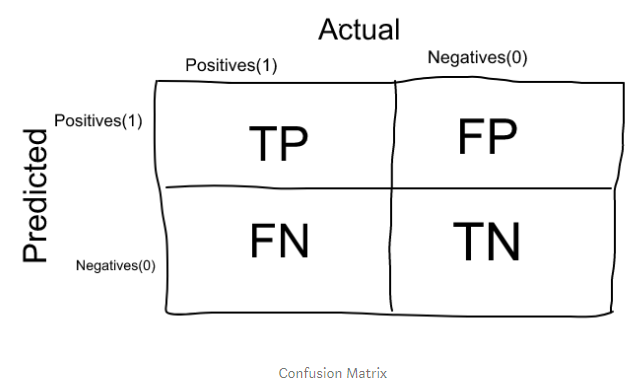

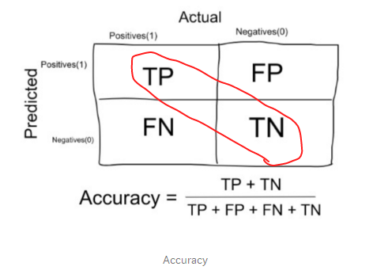

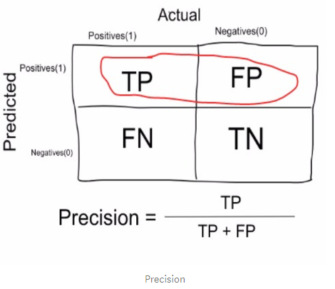

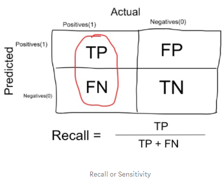

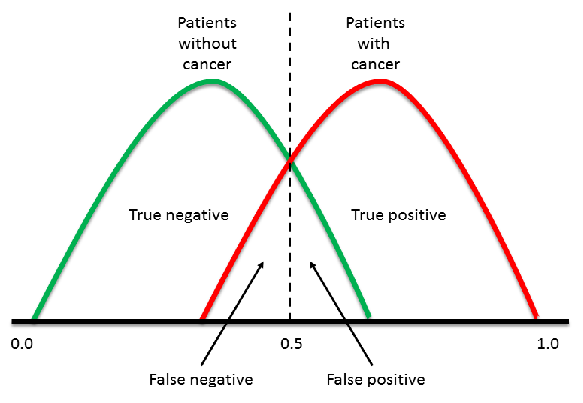

https://towardsdatascience.com/the-5-classification-evaluation-metrics-you-must-know-aa97784ff226

```python
print("The training accuracy is: ")
```

```
## The training accuracy is:
```

```python
print(accuracy_score(labels_train, svc_0.predict(features_train)))
```

```
## 0.960338445267
```

```python
print("Classification report")
```

```
## Classification report
```

```python
print(classification_report(labels_test,svc_pred))
```

```
##              precision    recall  f1-score   support
##
##           0       0.87      0.98      0.92        81
##           1       0.96      0.96      0.96        49
##           2       0.97      0.88      0.92        72
##           3       0.99      0.99      0.99        72
##           4       0.93      0.88      0.91        60
##
## avg / total       0.94      0.94      0.94       334
```

1. Undertake the text classification pipleine shown above over tweets on airlines to guage customer satisfaction. Your task is to determine the sentiment expressed in the tweet (positive or negative).

## Chapter 4: Sentiment Analysis/Opinion Mining - Classification

**Intended Learning Outcomes**  
1. Describe sentiment analysis.  
2. Describe how sentiment analysis could be used to determine sentiment around a new product.  
3. Give examples where sentiment in language may prove to be challenging to detect.  
4. List advantages of sentiment analysis systems.  
5. Describe how sentiment analysis can be undertaken.  
5. Identify main steps involved in building a machine learning based sentiment classifer.  
6. Take a data set and build a supervised based machine learning sentiment analysis classifer in Python.

### 4.1 What is Sentiment Analysis

Sentiment analysis is a text classification task. Give a phrase, or a list of phrases the classifier should indicate if the phrase is positive, negative or neutral.

Sentiment Analysis systems typically identify the following attributes of an expression:  
**Polarity:** if the speaker express a positive or negative opinion.  
**Subject:** the thing that is being talked about.  
**Opinion holder:** the person, or entity that expresses the opinion.

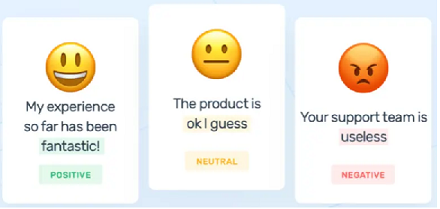

In essence: **“It is the process of determining the emotional tone behind a series of words, used to gain an understanding of the the attitudes, opinions and emotions expressed within an online mention”** *(Bannister, 2018)*.

Used in:

- Social Media Monitoring
- Electioneering
- Market Research/Customer Service

Sentiment analysis systems allow companies to make sense of the sea of unstructured text by automating business processes, getting actionable insights, and saving hours of manual data processing.

Sentiment analysis can be applied at different levels of scope:  
**Document level** sentiment analysis obtains the sentiment of a complete document or paragraph.  
**Sentence level** sentiment analysis obtains the sentiment of a single sentence.  
**Sub-sentence level** sentiment analysis obtains the sentiment of sub-expressions within a sentence.

There are many types and flavors of sentiment analysis am systems that focus on **polarity** (positive, negative, neutral) to systems that detect **feelings and emotions** (angry, happy, sad, etc) or **identify intentions** (e.g. interested v. not interested).

For example **Aspect-based sentiment analysis** indicates sentiment on different features related to a product.

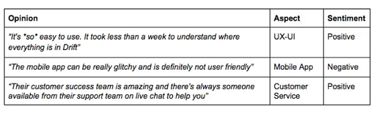

Another example is **Intent Analysis** basically detects what people want to do with a text rather than what people say with that text. Look at the following examples:

*“Your customer support is a disaster. I’ve been on hold for 20 minutes”.*

*“I would like to know how to replace the cartridge”.*

*“Can you help me fill out this form?”*  
A human being has no problems detecting the **complaint** in the first text, the **question** in the second text, and the **request** in the third text. However, machines can have some problems to identify those. Sometimes, the intended action can be inferred from the text, but sometimes, inferring it requires some contextual knowledge.

### 4.2 Challenges in Sentiment Analysis

Human language is complex. Teaching a machine to analyse the various grammatical nuances, cultural variations, slang and misspellings that occur in online mentions is a difficult process. Teaching a machine to understand how context can affect tone is even more difficult.

### 4.3 Advantages of sentiment analysis

**Scalability:**  
There’s just too much data to process manually. Sentiment analysis allows processing of data at scale in a efficient and cost-effective way.

**Real-time analysis:**  
Sentiment analysis can to identify critical information that allows situational awareness during specific scenarios in real-time.

**Consistent criteria:**  
By using a centralized sentiment analysis system, companies can apply the same criteria to all of their data. This helps to reduce errors and improve data consistency.

### 4.4 Practical Sentiment Analysis

There are many methods and algorithms to implement sentiment analysis systems, which can be classified as:  
**Rule-based systems** that perform sentiment analysis based on a set of manually crafted rules.  
**Automatic systems** that rely on machine learning techniques to learn from data.  
**Hybrid systems** that combine both rule based and automatic approaches.

Below, are steps that are typically undertaken in the building an **automatic sentiment analysis system**.

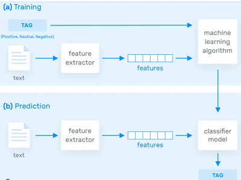

In a more practical sense, the objective here is to take text and produce a label (or labels) that summarizes the sentiment of this text, e.g. positive, neutral, and negative.

To solve this problem, typical machine learning pipeline is followed.

1. Import the required libraries and the dataset.
2. Exploratory data analysis.
3. Text Preprocessing.
4. Apply machine learning algorithms to train and test our sentiment analysis models.

**Import the Dataset**

```python
airline_tweets = pd.read_csv("C:/data/tweets/Tweets.csv")
airline_tweets.head()
```

```
##              tweet_id airline_sentiment  airline_sentiment_confidence  \
## 0  570306133677760513           neutral                        1.0000
## 1  570301130888122368          positive                        0.3486
## 2  570301083672813571           neutral                        0.6837
## 3  570301031407624196          negative                        1.0000
## 4  570300817074462722          negative                        1.0000
##
##   negativereason  negativereason_confidence         airline  \
## 0            NaN                        NaN  Virgin America
## 1            NaN                     0.0000  Virgin America
## 2            NaN                        NaN  Virgin America
## 3     Bad Flight                     0.7033  Virgin America
## 4     Can't Tell                     1.0000  Virgin America
##
##   airline_sentiment_gold        name negativereason_gold  retweet_count  \
```

[output cut: 19 more lines]

**Exploratory Data Analysis**

```python
import operator
import pandas as pd
import re
import sklearn
from sklearn.decomposition import PCA
from sklearn import feature_extraction
from sklearn.feature_extraction.text import CountVectorizer, TfidfVectorizer
from nltk import ngrams
from nltk.stem import PorterStemmer
from nltk.stem import WordNetLemmatizer
from nltk.corpus import stopwords
from nltk.corpus import brown
from nltk.collocations import *
from nltk.corpus import webtext
import numpy as np
import random
import pickle
import pandas as pd
from sklearn.metrics.pairwise import cosine_similarity

airline_tweets = pd.read_csv("C:/data/tweets/Tweets.csv")
airline_tweets.head()
```

```
##              tweet_id airline_sentiment  airline_sentiment_confidence  \
## 0  570306133677760513           neutral                        1.0000
## 1  570301130888122368          positive                        0.3486
## 2  570301083672813571           neutral                        0.6837
## 3  570301031407624196          negative                        1.0000
## 4  570300817074462722          negative                        1.0000
##
##   negativereason  negativereason_confidence         airline  \
## 0            NaN                        NaN  Virgin America
## 1            NaN                     0.0000  Virgin America
## 2            NaN                        NaN  Virgin America
## 3     Bad Flight                     0.7033  Virgin America
## 4     Can't Tell                     1.0000  Virgin America
##
##   airline_sentiment_gold        name negativereason_gold  retweet_count  \
```

[output cut: 19 more lines]

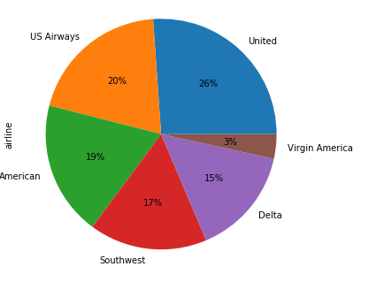

```python
library(reticulate)
reticulate::repl_python()

airline_tweets.airline.value_counts().plot(kind='pie', autopct='%1.0f%%')
plt.show()
```

```python
airline_tweets.airline_sentiment.value_counts().plot(kind='pie', autopct='%1.0f%%', colors=["red", "yellow", "green"])
```

[figure not shown]

```python
airl= list(set(list(airline_tweets['airline'])))
pos=[]
neg=[]
neut=[]

for airlines in airl:
    filter = (airline_tweets['airline'] == airlines) & (airline_tweets['airline_sentiment'] == 'negative')
    num = len(airline_tweets[filter])
    neg.append(num)
    filter = (airline_tweets['airline'] == airlines) & (airline_tweets['airline_sentiment'] == 'positive')
    num = len(airline_tweets[filter])
    pos.append(num)
    filter = (airline_tweets['airline'] == airlines) & (airline_tweets['airline_sentiment'] == 'neutral')
    neut = len(airline_tweets[filter])


data = [pos,neg,neut]


fig, ax = plt.subplots()
ax.set_xticks(range(len(airl)))
ax.set_xticklabels(airl, rotation='vertical')
X = np.arange(6)
ax.bar(X + 0.00, data[0], color = 'b', width = 0.25)
ax.bar(X + 0.25, data[1], color = 'g', width = 0.25)
ax.bar(X + 0.50, data[2], color = 'r', width = 0.25)

plt.show()
```

[output not shown]

Plotting a puie chart in Python -further help https://pythonspot.com/matplotlib-pie-chart/

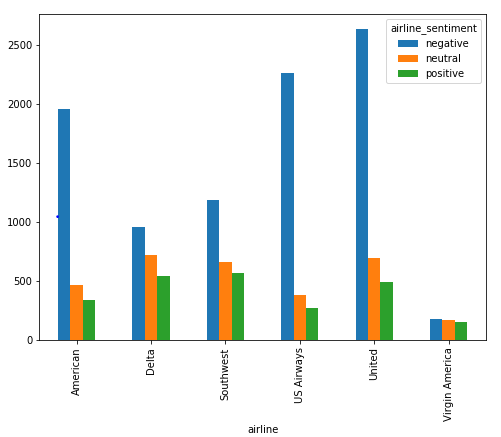

```python
import seaborn as sns

airline_sentiment = airline_tweets.groupby(['airline', 'airline_sentiment']).airline_sentiment.count().unstack()
airline_sentiment.plot(kind='bar')
```

**Data Cleaning**

Tweets contain many slang words and punctuation marks. The tweets will have to be cleaned before they can be used for training the machine learning model.

Before cleaning the tweets, the dataset should be split into into **feature** and **label sets**.

```python
features = airline_tweets.iloc[:, 10].values
labels = airline_tweets.iloc[:, 1].values

print(features[1:5])
```

```
## ["@VirginAmerica plus you've added commercials to the experience... tacky."
##  "@VirginAmerica I didn't today... Must mean I need to take another trip!"
##  '@VirginAmerica it\'s really aggressive to blast obnoxious "entertainment" in your guests\' faces &amp; they have little recourse'
##  "@VirginAmerica and it's a really big bad thing about it"]
```

```python
print(labels[1:5])
```

```
## ['positive' 'neutral' 'negative' 'negative']
```

Now, the tweets should be cleaned. Functions developed in the introduction to NLP could be used, howevever knowing how to use regular expression is a key skill in NLP and will be used here to clean the text. Further information on how to use regular expressions in Python can be found here: https://stackabuse.com/using-regex-for-text-manipulation-in-python/

```python
processed_features = []

for sentence in range(0, len(features)):
    # Remove all the special characters
    processed_feature = re.sub(r'\W', ' ', str(features[sentence]))

    # remove all single characters
    processed_feature= re.sub(r'\s+[a-zA-Z]\s+', ' ', processed_feature)

    # Remove single characters from the start
    processed_feature = re.sub(r'\^[a-zA-Z]\s+', ' ', processed_feature)

    # Substituting multiple spaces with single space
    processed_feature = re.sub(r'\s+', ' ', processed_feature, flags=re.I)

    # Removing prefixed 'b'
    processed_feature = re.sub(r'^b\s+', '', processed_feature)

    # Converting to Lowercase
    processed_feature = processed_feature.lower()

    processed_features.append(processed_feature)
print (processed_feature[12])
```

[output not shown]

**Representing Text in Numeric Form**

To make statistical algorithms work with text, we first have to convert text to numbers. See Intro to NLP, section on vectorisation.  
The tweets will be scored using TF-IDF mechanism.

```python
from nltk.corpus import stopwords
from sklearn.feature_extraction.text import TfidfVectorizer

vectorizer = TfidfVectorizer (max_features=2500, min_df=7, max_df=0.8, stop_words=stopwords.words('english'))
processed_features = vectorizer.fit_transform(processed_features).toarray()
```

In the code above, we define that the max_features should be 2500, which means that it only uses the  
2500 most frequently occurring words to create a bag of words feature vector. Words that occur less frequently are not very useful for classification.

Similarly, max_df specifies that only use those words that occur in a maximum of 80% of the documents.  
Words that occur in all documents are too common and are not very useful for classification.  
Similarly, min-df is set to 7 which shows that include words that occur in at least 7 documents.

**Dividing Data into Training and Test Sets**  
Before we train our algorithms, we need to divide our data into **training and testing sets**. The training set will be used to train the algorithm while the test set will be used to evaluate the performance of the machine learning model.

```python
X_train, X_test, y_train, y_test = train_test_split(processed_features, labels, test_size=0.2, random_state=0)
```

The train_test_split class from the sklearn.model_selection module to divide our data into **training and testing set**. The method takes the feature set as the first parameter, the label set as the second parameter, and a value for the test_size parameter. A value of 0.2 for test_size is specified which means that our data set will be split into two sets of 80% and 20% data. The 80% dataset will be used for training and 20% dataset for testing.

**Training the Model**

The Random Forest algorithm will be used due to its ability to act upon non-normalized data.

The sklearn.ensemble module contains the RandomForestClassifier class that can be used to train the machine learning model using the random forest algorithm.  
First a call to the fit method on the RandomForestClassifier class is performed. This is then passed to the training features and labels, as parameters.  
&nbsp

```python
from sklearn.ensemble import RandomForestClassifier

text_classifier = RandomForestClassifier(n_estimators=200, random_state=0)
text_classifier.fit(X_train, y_train)
```

```
## RandomForestClassifier(bootstrap=True, class_weight=None, criterion='gini',
##             max_depth=None, max_features='auto', max_leaf_nodes=None,
##             min_impurity_decrease=0.0, min_impurity_split=None,
##             min_samples_leaf=1, min_samples_split=2,
##             min_weight_fraction_leaf=0.0, n_estimators=200, n_jobs=1,
##             oob_score=False, random_state=0, verbose=0, warm_start=False)
```

**Making Predictions and Evaluating the Model**  
Once the model has been trained, the last step is to make predictions on the model.  
To do so, a call is made to the predict method on the object of the RandomForestClassifier class that we used for training.  
Look at the following script:

```python
predictions = text_classifier.predict(X_test)
```

Finally, to evaluate the performance of the machine learning models, classification metrics such as a confusion metrix, F1 measure, accuracy are employed as shown below.

```python
from sklearn.metrics import classification_report, confusion_matrix, accuracy_score

print(confusion_matrix(y_test,predictions))
```

```
## [[1723  108   39]
##  [ 326  248   40]
##  [ 132   58  254]]
```

```python
print(classification_report(y_test,predictions))
```

```
##              precision    recall  f1-score   support
##
##    negative       0.79      0.92      0.85      1870
##     neutral       0.60      0.40      0.48       614
##    positive       0.76      0.57      0.65       444
##
## avg / total       0.75      0.76      0.74      2928
```

```python
print(accuracy_score(y_test, predictions))
```

```
## 0.759904371585
```

Different Python libraries were used to contribute to performing sentiment analysis. An analysis was done on public tweets regarding six US airlines and achieved an accuracy of around 75%.

References:

https://medium.com/seek-blog/your-guide-to-sentiment-analysis-344d43d225a7 https://stackabuse.com/python-for-nlp-sentiment-analysis-with-scikit-learn/ https://monkeylearn.com/sentiment-analysis/